# Data Exploration Project Memo - Student Adaptivity to Online Learning

Group 6 - Cam Nguyen, Anson Lo, Tiffany Wibisono, Kalina Gavrilova, Lauren Louie, Jasmine Phan

2022-06-08

As current university students who spent a large proportion of our undergraduate years learning from home during the COVID-19 pandemic, our group was particularly interested in exploring a data set about the unique challenges imposed on students by at-home learning. The data set that we explored was made up of student observations collected from December 10, 2020 to February 5, 2021 in Bangladesh, and consisted of several variables describing the adaptability level of students to online learning during the pandemic. The main variables that we chose to focus on in our exploration included the duration of class time per day, education level of the students, and financial condition of the students.

We decided to explore the relationships between these different variables and determine which factors play the largest role in a student’s ability to succeed in an online learning environment, described in the data as their “adaptivity level”- a ranking based on the students’ reports about how well they considered their online education to be going. The first variable considered was the students’ financial condition, based on the relative wealth of their family or primary source of financial support.

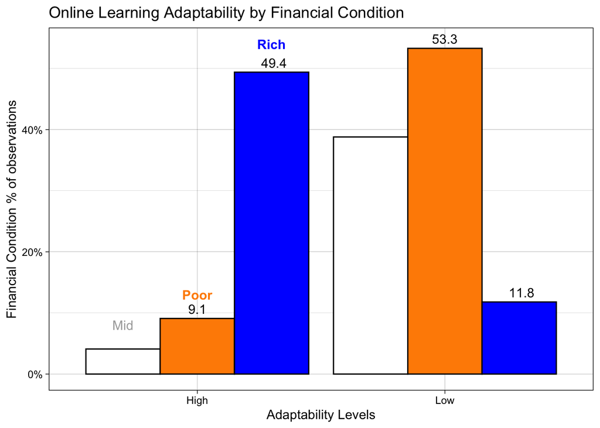

There is significant disparity among wealthy and poor students in their adaptivity to online learning, with roughly half of wealthy students falling into the high adaptivity category, compared to less than one-tenth of poor students. This indicates that financial condition plays a very large part in determining a student’s success in an online learning environment, perhaps more than any other factor considered. Despite global efforts to ease the financial burden of the COVID-19 pandemic, it seems that low-income individuals suffer the brunt of these consequences in pursuing their education.

The next variable considered was students’ age ranges and level of adaptability.

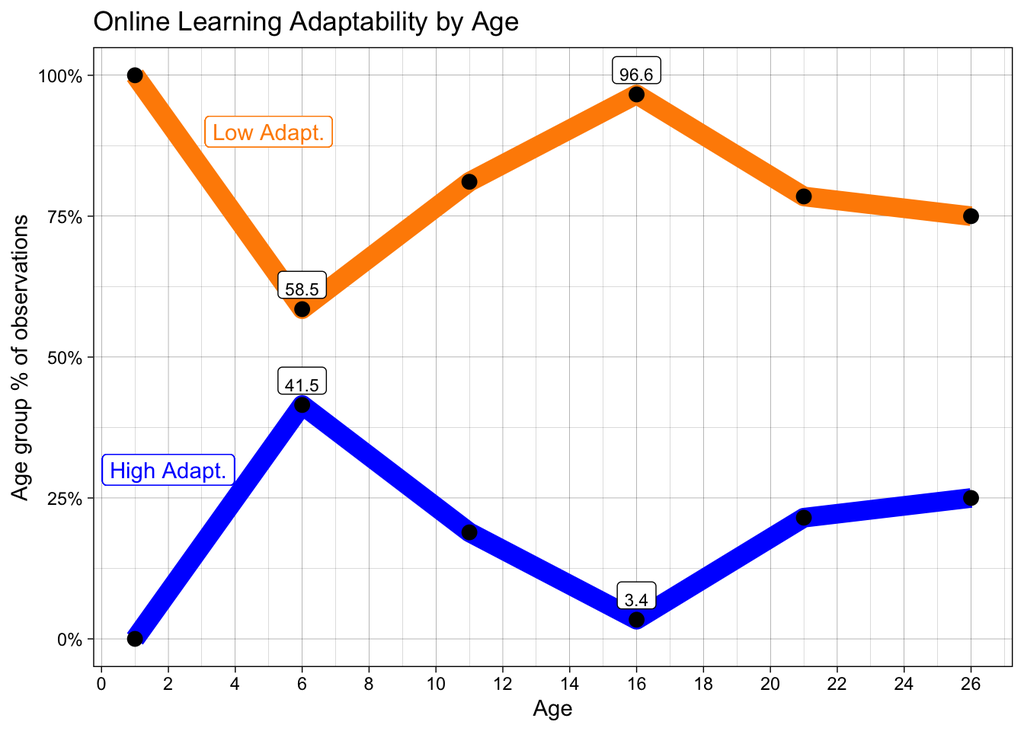

To see how much of this difference in financial condition is related to the public or private status of the schools, we considered the relationship between student financial level and type of institution

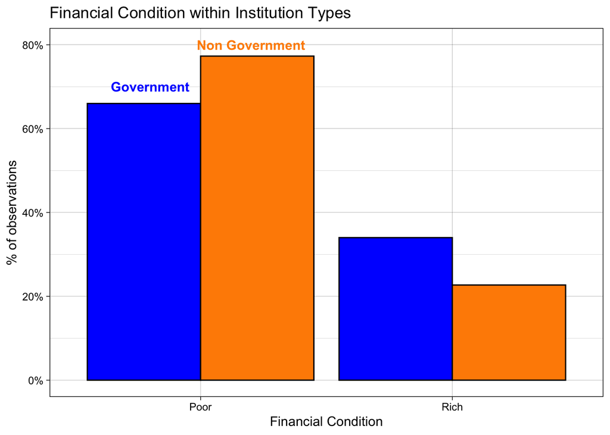

A larger proportion of low-income students attend private institutions, which contradicted our expectations. Private schools are generally considered a better education than public schools. Children in the “Poor” Financial Condition might be investing more into education because of the lack of other resources and extremely inadequate government education. This could be explained by greater private funding in private institutions generating higher merit scholarships compared to scholarships at private institutions, which are funded through the government.

Next, we considered how the duration of classes impacted the students’ adaptivity.

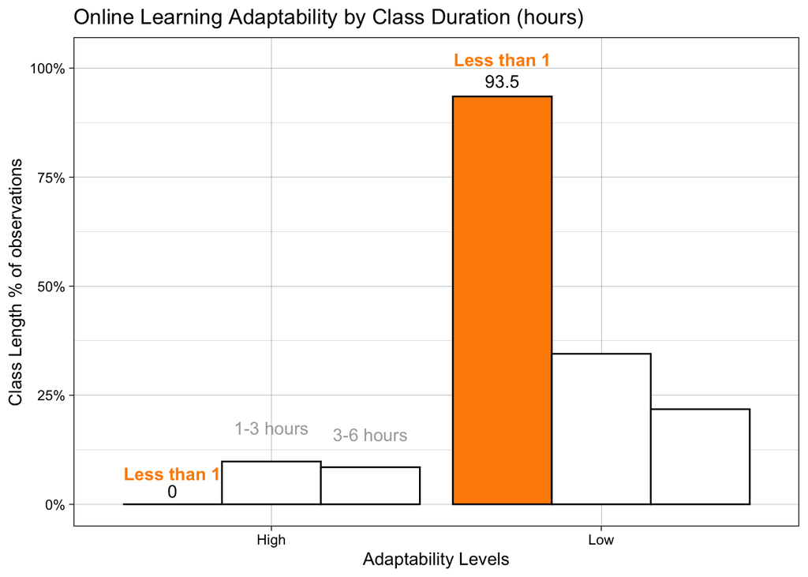

Interestingly, there is little difference between classes with a 1-3 hour daily average, and classes with a 3-6 hour daily average. There is, however, a dramatic impact on student adaptivity when it comes to classes that are less than an hour, which have a significantly larger rate of low student adaptivity.This would suggest that at least an hour of class time is beneficial -perhaps this has to do with greater opportunity for students to ask questions in real time, bond more with their peers and teachers, and understand concepts in greater detail through lectures.Without the typical class environment, students need online synchronicity.

Finally, to consider how different institutions fare in student adaptivity, we considered the differences in adaptivity among college students and university students.

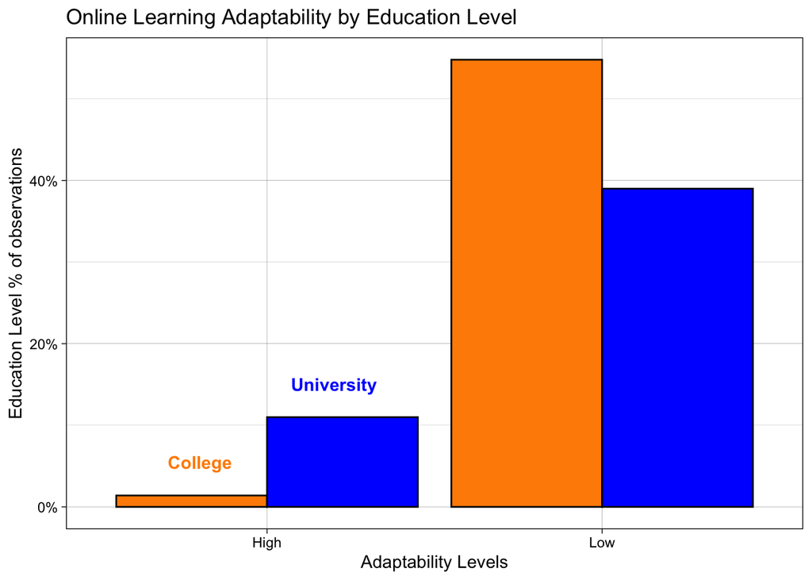

Compared to universities, colleges had lower levels of adaptivity among their students. Regardless of which factors contribute to this disparity, this distinction is interesting and potentially important in considering the distribution of government funding across different institution types (as there are both public and private colleges and universities considered in the data). Based on the large difference between colleges and universities regarding student adaptivity, it is worth considering that online-learning resources would more greatly benefit college students.